# Data Cleaning

**Link to notebook:** https://colab.research.google.com/drive/1juLOJKbuAjSnLAvU-uPuAWKZVTUkLmyR

```python
import pandas as pd
import json
import numpy as np

import matplotlib.pyplot as plt
```

## Getting the data and mergeing them to one dataframe.

The dataset consists of many (55) smaller datasets, which need to be merged into one. We'll start by unzipping them.

```python
!wget https://s3.amazonaws.com/weruns/forfun/Kickstarter/Kickstarter_2019-10-17T03_20_19_421Z.zip
!unzip Kickstarter_2019-10-17T03_20_19_421Z.zip
```

[output not shown]

[output cut: 14 more lines]

[output not shown]

```python
kickstarter_full=pd.DataFrame()

for i in range(1,56):
  try:
    df = pd.read_csv('/content/Kickstarter00'+str(i)+'.csv')
    kickstarter_full=pd.concat([kickstarter_full,df], sort=False,ignore_index=True)
  except:
    df = pd.read_csv('/content/Kickstarter0'+str(i)+'.csv')
    kickstarter_full=pd.concat([kickstarter_full,df], sort=False,ignore_index=True)

kickstarter_df=kickstarter_full.reset_index(drop=True)
```

```python
kickstarter_df.columns
```

```
Index(['backers_count', 'blurb', 'category', 'converted_pledged_amount',
       'country', 'country_displayable_name', 'created_at', 'creator',
       'currency', 'currency_symbol', 'currency_trailing_code',
       'current_currency', 'deadline', 'disable_communication', 'friends',
       'fx_rate', 'goal', 'id', 'is_backing', 'is_starrable', 'is_starred',
       'launched_at', 'location', 'name', 'permissions', 'photo', 'pledged',
       'profile', 'slug', 'source_url', 'spotlight', 'staff_pick', 'state',
       'state_changed_at', 'static_usd_rate', 'urls', 'usd_pledged',
       'usd_type'],
      dtype='object')
```

```python
kickstarter_df.shape
```

```
(201500, 38)
```

## Choosing the features

*So what should we keep?* We've inspected the dataset, containing all of the above columns. First, we found various columns that contains almost exclusively NaNs, which we deleted. Additionally, we wanted to make predictions on the Kickstarter success, with no information that is not known when launching a campaign. This implied that all columns pertaining information about the final amount of money that have been pledged were deleted.

Left were the following columns, used as features for the various models.

- ID - An identification code.
- Name - The (string) name of the project.
- blurb - The (string) description of the project.
- launched_at, created_at, deadline - three columns with date data.
- disable_communication - A (boolean) choice by creators, opting to NOT communicate with their backers.
- is_starable - A (boolean) choice by Kickstarter, allowing certain campaigns to achieve a 'starred' recommendation.
- static_usd_rate - A rate pertaining currency info specifically to USD (the currency used for all purposes here).
- fx_rate - the foreign exchange rate.
- goal - the monetary goal of the campaign to become successful.
- category - A dictionary containing main and sub categories.
- country - (string) country name
- photo - photo URLs, to be scraped for Computer vision algorithm
- staff pick - A (boolean) recommendation by Kickstarter
- Target: state (sucessful/failed) - the very thing we try to predict

```python
# The dataframe we'll work with from here.
data=kickstarter_df[['id','name','blurb','created_at','launched_at', 'disable_communication',
                     'is_starrable', 'static_usd_rate', 'deadline','fx_rate','goal','category','country','photo', 'staff_pick','state']]
```

```python
data.shape
```

```
(201500, 16)
```

## 'Refining' the features

### Simple conversions

We have three columns (wait_time, run_time, USD_goal), which need some simple conversions, herein creating one common currency for the goal, taking into account the foreign exchange rate.

```python
wait=data.launched_at-data.created_at
run=data.deadline-data.launched_at
usd_goal=round(data.goal*data.fx_rate)
```

From here, we'll insert those new columns, dropping the now redundant old ones.

```python
data.insert(3, 'wait_time', wait)
data.insert(4, 'run_time', run)
data.insert(5, 'USD_goal', usd_goal)
data.drop(columns=['created_at','launched_at','deadline','fx_rate','goal'],inplace=True)
```

```python
print(data.wait_time[:3])
print(data.run_time[:3])
print(data.USD_goal[:3])
```

```
0       3222
1     574486
2    2516830
Name: wait_time, dtype: int64
0    3456000
1    5180400
2    1716946
Name: run_time, dtype: int64
0    3000.00
1   75000.00
2   35000.00
Name: USD_goal, dtype: float64
```

### Encode contries

The 'country' column is a string that we know we'd like to include into our later models (non-neural and neural) that work with numerical data. So, we have decided to use One-Hot encoding.

```python
data.shape
```

```
(201500, 14)
```

```python
from sklearn.preprocessing import OneHotEncoder
onehot_encoder = OneHotEncoder(sparse=False)
```

```python
encoded_country = pd.DataFrame(onehot_encoder.fit_transform(data.country.values.reshape(-1, 1)))
encoded_country.shape
```

```
(201500, 22)
```

```python
encoded_country.columns = ['country_'+str(col_name) for col_name in encoded_country.columns]
```

```python
data=data.join(encoded_country) # The last columns with names country_0-country_21 are dummy variables for the country
data.drop(columns=['country'],inplace=True)
```

### Photo

The 'photo' column contains URLs for the photos used in the Kickstarter campaigns. The below is a test just to inspect various photos. A scraper (other notebook) is then built to fetch and download the main photo from each campaign,into a local folder.

Extracting just one url from the photo dictionary.

```python
photo=[json.loads(img).get('full') for img in data.photo] #Posible keys: full, ed, med, little, small, thumb, 1024x576, 1536x864
```

```python
data['photo']=photo
```

```python
data.photo[np.random.randint(1000)]
```

```
'https://ksr-ugc.imgix.net/assets/012/014/935/2541401e66c38e4ac0ce1e22e7de4d3f_original.jpg?ixlib=rb-2.1.0&crop=faces&w=560&h=315&fit=crop&v=1463724182&auto=format&frame=1&q=92&s=4c93691a5538e7751c416eb0888e8992'
```

### Category

The 'category' column is a bit of a mess, as seen below..

```python
data['category'][1]
```

```
'{"id":338,"name":"Robots","slug":"technology/robots","position":10,"parent_id":16,"color":6526716,"urls":{"web":{"discover":"http://www.kickstarter.com/discover/categories/technology/robots"}}}'
```

So we wish to extract the name of the general category from the category dictionary.

```python
from sklearn.preprocessing import OneHotEncoder
```

```python
data.category[1]
category=[json.loads(dict).get('slug') for dict in data.category]
```

```python
import re
```

```python
category=[re.sub(r'\/.+','',cat) for cat in category] #Getting ie. technology instead of robot
```

```python
data['category']=category
data.category[1]
```

```
'technology'
```

```python
onehot_encoder2 = OneHotEncoder(sparse=False)
```

```python
encoded_category = pd.DataFrame(onehot_encoder2.fit_transform(data.category.values.reshape(-1, 1)))
encoded_category.shape
```

```
(201500, 15)
```

```python
encoded_category.columns = ['cat_'+str(col_name) for col_name in encoded_category.columns]
```

```python
data=data.join(encoded_category) # The last columns with names cat_0-cat_14 are dummy variables for the category
data.drop(columns=['category'],inplace=True)
```

### Exploring State (successful/failed), i.e. balance of dataset

We found that sucess and faliure aren't the two only 'states' for a campaign, so what are the others and what do we do with them?

```python
data.state.value_counts()
```

```
successful    114006
failed         71365
canceled        8356
live            7154
suspended        619
Name: state, dtype: int64
```

We have choosen to only keep successful and failed campaigns, keeping it as a binary target. Whether a campaing is live, suspended or canceled is of no interest, since so many reasons might come in to play as to why a campaign is e.g. canceled or suspended.

```python
df=data[(data.state == 'successful') | (data.state == 'failed')]
```

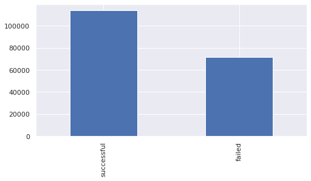

```python
df['state'].value_counts().plot(kind='bar')
```

Inspecting the ratio of succesful/failed projects is important, seeing as working with binary predictions of an *imbalanced* dataset might cause the model to predict very accurately, because it guesses the most frequent state, regardless. In such a case other evaluation metrics would be more fruitful, such as 'precision'. Luckily, our dataset is fairly balanced and large enough that is shouldn't cause inconvenience.